# Introducing Python

## Iterating over values - for loops

The for loop needs a colon (:) and everything after that (related to the for loop) must be indented.

We can use for loops to do lots of great things, but it is very important you know how they work - make sure you print out your values to check it is doing what you want it to.

### Example

Write a for loop to print out the index of the loop and 2 times the index of the loop.

### Solution

Click below to see the solution.

```python
for k in range(1, 10):
    print('k in loop: ',k,'2k in loop:',(2*k))
```

```
k in loop:  1 2k in loop: 2
k in loop:  2 2k in loop: 4
k in loop:  3 2k in loop: 6
k in loop:  4 2k in loop: 8
k in loop:  5 2k in loop: 10
k in loop:  6 2k in loop: 12
k in loop:  7 2k in loop: 14
k in loop:  8 2k in loop: 16
k in loop:  9 2k in loop: 18
```

### Example

Write a for loop to print out "I have a pet...." for all of the animals in the list animals = ["lemur","panda","shark","bat"].

Write another loop to print out all the letters in "sloth".

### Solution

Click below to see the solution.

```python
animals=["lemur","panda","shark","bat"]

for item in animals:
    print("I have a pet " + item)

print()
for item in "sloth":
    print(item)
```

```
I have a pet lemur
I have a pet panda
I have a pet shark
I have a pet bat

s
l
o
t
h
```

### Example

Calculate the position of a falling body in free-fall from $t=0$s to 1000s in steps of 50s.

### Solution

Click below to see the solution.

```python
t=range(0,1000,50)
# set up an array of times which starts at t=0, ends at t =
# 1000s in steps of 50s

# now call the equation for each time by using the for loop:
for i in range(0,len(t)):   # each value of t is called as t[i] where i is an index
                            # from t[start] to t[end]
    y = 0.5*g*t[i]**2+v_0*t[i]+y_0
    print(y)
```

```
1.35
12326.85
49177.35
110552.85
196453.35
306878.85
441829.35
601304.85
785305.35
993830.85
1226881.35
1484456.85
1766557.35
2073182.85
2404333.35
2760008.85
3140209.35
3544934.85
3974185.35
4427960.85
```

If instead we used the following code, we would only get the last value of $y$.

```python
# now call the equation for each time by using a for loop:
for i in range(0,len(t)):
    y = 0.5*g*t[i]**2+v_0*t[i]+y_0

print(y)
print('so we see we only get one value of y if we print outside the for loop')

print()
# though we should use the following for our print statement:
print('Note: the correct way to write this would be something like:')
print('The position of body in free fall at t=1000s is {:.2e} m'.format(y))
```

```
4427960.85
so we see we only get one value of y if we print outside the for loop

Note: the correct way to write this would be something like:
The position of body in free fall at t=1000s is 4.43e+06 m
```

### Append and factorising code

One way to get around this issue (where you can only get the values of $y$ for all $t$ inside the for loop and not outside) is to use Python `append` function.

A much simpler alternative way of calculating $y$ for every value of $t$ without having to do the for loop iteration over each $t$ value is shown below (in fact we can do it in one line).

```python
y = [] # tell the code that y will have more than one value

for i in range(0,len(t)):
    y.append(0.5*g*t[i]**2+v_0*t[i]+y_0)

print('using a loop to calculate y for each value of t and then append all values to a list gives')
print(y)

print()
print(r'or we can write the following code: y = [0.5*g*x**2+v_0*x+y_0 for x in t] to give:')
# the little r in the line above tells python you want to print out exactly what you have written!
print()

y2 = [0.5*g*x**2+v_0*x+y_0 for x in t]
print(y2)
```

```
using a loop to calculate y for each value of t and then append all values to a list gives
[1.35, 12326.85, 49177.35, 110552.85, 196453.35, 306878.85, 441829.35, 601304.85, 785305.35, 993830.85, 1226881.35, 1484456.85, 1766557.35, 2073182.85, 2404333.35, 2760008.85, 3140209.35, 3544934.85, 3974185.35, 4427960.85]

or we can write the following code: y = [0.5*g*x**2+v_0*x+y_0 for x in t] to give:

[1.35, 12326.85, 49177.35, 110552.85, 196453.35, 306878.85, 441829.35, 601304.85, 785305.35, 993830.85, 1226881.35, 1484456.85, 1766557.35, 2073182.85, 2404333.35, 2760008.85, 3140209.35, 3544934.85, 3974185.35, 4427960.85]
```

*Yay - we have basically saved all the values of y into one list.*

### Data types

Now there may be times when you wish to take your list of $y$ values and do some mathematical operations on them, for example what is $y^2$? Naively we might think we can simply just multiply all the values in our $y$ list by itself.

[figure not shown]

Obviously this has not worked. This is because it's a list and we can't multiply a list this way (we'd have to do another for loop). To find out if you have a list or an array you can use the `type` command. We will return to `numpy` arrays later.

We can convert our Python list into a Python array using `numpy` and then do mathematical calculations with our data - let's say $y^2$ for example by using the following code

```
y_arr = np.array(y)
y_sq = y_arr*y_arr
print(y_sq)
```

### Example

Find out the types of the following `a=1`, `b=1.0`, and `c="1.0"`.

### Solution

Click below to see the solution.

```python
a=1; b=1.0; c='1.0'

print(type(a))
print(type(b))
print(type(c))
```

```
<class 'int'>
<class 'float'>
<class 'str'>
```

So what is the type of our data $y (t)$?

```python
print(type(y))
```

```
<class 'list'>
```

It's a list!

## If Statements

If statements allow us to have conditions. For example, if the speed of the falling body goes above a critical speed $v_{\rm crit}$, then perhaps a different equation applies.

### Example

You are asked whether you have any symptoms of a fever or a continuous cough. Use Python `if` statements to print an appropriate message if the answer to this question is yes, no, or not sure.

### Solution

Click below to see the solution.

```python
your_symptoms = "ill"

if your_symptoms == 'ill':
    print('You are '+ your_symptoms + ' - You need to go home and rest in isolation.')
elif your_symptoms == 'not ill':
    print('You are '+ your_symptoms +' - OK, take care of yourself.')
elif your_symptoms == 'not sure':
    print('You are '+ your_symptoms + '- Best to be safe and go home and rest.')
else:
    print('I am sorry, I do not know what to say.')
```

```
You are ill - You need to go home and rest in isolation.
```

Note that here we are making use of strings `" "` instead of numbers.

### Example

Let's suppose we want to estimate the position of a body falling in free fall $y$ only when $t \leq 100$s. At any other times, we set it to equal to zero (ie they hit the ground at 100s). We can do this using Python `if` statements.

### Solution

Click below to see the solution.

```python
y = []

for i in range(0,len(t)):
    if (t[i] <= 100):
        y.append(0.5*g*t[i]**2+v_0*t[i]+y_0)
    else:
        y.append(0.)

print(y)
```

```
[1.35, 12326.85, 49177.35, 0.0, 0.0, 0.0, 0.0, 0.0, 0.0, 0.0, 0.0, 0.0, 0.0, 0.0, 0.0, 0.0, 0.0, 0.0, 0.0, 0.0]
```

In these examples you will see that Python tests for equality uses the `==` to separate it from the `a = [1,2,3,4,5]` assignments of variables. We can also use `<`, `<=`, `>=` and `>` in Python code.

## Arrays

In science we often have data $x_0, x_1, x_2, ..., x_{n-1}$ and related $y_0, y_1, y_2, ..., y_{n-1}$. We can use a Python list a for the $x$ values with elements a[0], a[1], a[3],..., a[n-1] and so on. Python lists can contain any type of Python object, but sometimes we want one to contain numbers only. We can use arrays, which can be mutidimensional (eg 3x3 array instead of the 1d list). Python arrays are lists of objects of the same type and can make your code faster if you use them.

### Example

Convert the $y(t)$ values from above (which are currently in a Python list) into an array and check it has worked.

### Solution

Click below to see the solution.

```python
y = np.array(y)

print(type(y))
```

```
<class 'numpy.ndarray'>
```

### arange

It works! We have used `numpy` to convert our list of values into an array that can be manipulated mathematically.

As we used `range` earlier to make a list of time array of values, we can use `np.arange()` to make an array of time values. Examples are below:

```python
a = np.arange(10) # make an array with 10 values (produces integers)

print(a)
```

```
[0 1 2 3 4 5 6 7 8 9]
```

```python
a = np.arange(0,10,1) # now go from 0-10 in steps of 1 (produces integer)
print('a=',a)


b = np.arange(0,10,0.5)  #now go from 0-10 in steps of 0.5 (produces float)
print('b=',b)
```

```
a= [0 1 2 3 4 5 6 7 8 9]
b= [0.  0.5 1.  1.5 2.  2.5 3.  3.5 4.  4.5 5.  5.5 6.  6.5 7.  7.5 8.  8.5
 9.  9.5]
```

How can we check the types of the numbers in a and b? Are they integers or floats? If we use `type(a)` this gives us the type of a (an array) so we need to call one of the numbers in the array and check it's type. We will do this using the 1st value in the array `a[0]`.

```python
# what is the type of the 1st number in a
# what is the type of the 1st number in b
print('The type of 1st number in a is', type(a[0]), '-- is it an integer? Yes.')
print('The type of 1st number in b is', type(b[0]), '-- is it a float? Yes.')
```

```
The type of 1st number in a is <class 'numpy.int64'> -- is it an integer? Yes.
The type of 1st number in b is <class 'numpy.float64'> -- is it a float? Yes.
```

### Slicing data, getting subsets of data

Some examples of slicing data samples where `a` is an array of data with length `len(a)` and has a starting data point `a[0]` and an end data point `a[len[a]-1]`. We call the starting and ending data points we wish to pull out of the array `start` and `stop` in the examples below.

`a[start:stop]` ---- items start through stop-1

`a[start:]` ---- items start through the rest of the array

`a[:stop]` ---- items from the beginning through stop-1

`a[:]` ---- a copy of the whole array

`a[start:stop:step]` ---- can have a step size to pull out say every 100 points from the array

### Tip

You can use `numpy` to get the min, max and mean, standard deviation for your arrays using `np.mean(a)` etc.

## Equations and functions

If you have to use the same function a few times, or you like tidy code, it's easiest to define a function. Here is an example function for $y=x^2+2$.

```python
def my_equation(x):
    return x**2+2
```

```python
a = 3.4

print(my_equation(a))
```

```
13.559999999999999
```

```python
print('for a =  3.4s, the equation gives {:.2f}'.format(my_equation(a))) # no units given in question.
```

```
for a =  3.4s, the equation gives 13.56
```

### Example

Write a function for the position of a body falling in free fall for time $t=30$s. The initial speed and position are 3m/s and 1m.

### Solution

Click below to see the solution.

```python
def position(time,accel,v_init,y_init):
    value = 0.5*accel*time**2+v_init*time+y_init
    return value

t = 30.
g = 9.81
v_0 = 3.
y_0 = 1.

y = position(t,g,v_0,y_0)

print('at t =  30s, the value of position is {:.2f} m'.format(y))
```

```
at t =  30s, the value of position is 4505.50 m
```

### Example

Now get values of the position of a body falling in free fall for times from $t=0$s to $t=100s$ in steps of 10s. The initial speed and position are 3m/s and 1m.

### Solution

Click below to see the solution.

```python
t = np.arange(0,100,10) # set up time values

y = position(t,g,v_0,y_0)

print('time in secs',t)
print('position in m',y)
```

```
time in secs [ 0 10 20 30 40 50 60 70 80 90]
position in m [1.00000e+00 5.21500e+02 2.02300e+03 4.50550e+03 7.96900e+03 1.24135e+04
 1.78390e+04 2.42455e+04 3.16330e+04 4.00015e+04]
```

Now we can use a for loop to print this out nicely so that we have $t$ and $y$ values in columns:

```python
for i in range(0,len(t)):
    y = position(t[i],g,v_0,y_0)
    print(t[i],y)
```

```
0 1.0
10 521.5
20 2023.0
30 4505.5
40 7969.0
50 12413.5
60 17839.0
70 24245.5
80 31633.0
90 40001.5
```

## Importing data files

The data file you want to export must be in the same directory as the notebook or you will need to tell the notebook where to look for the file. You can upload the file to Google Colab. In this example we will use the `numpy` package (shortened to `np`) and call the `numpy` `genfromtxt` tool to read the data file:

`data = np.genfromtxt('file.dat')`

Sometimes an error occurs with the `np.genfromtxt`. If this happens, you might want to skip the first row (often in data files there are words in the first row, known as the header information. To get around this you can use:

`data = np.genfromtxt('file.dat',skip_header=1)`

Sometimes you need to specify the delimiter in the data file (tab/space/comma), in this case it looks like:

`data = np.genfromtxt('file.dat',delimiter=' ')`

(Note you can also use `np.loadtxt`).

### Example

Read in the data file DataAnalysis_testfile.dat and print it out. You can find this file [here](https://github.com/haleygomez/Data-Analysis-2021/raw/master/blended_exercises/Chapter%201/DataAnalysis_testfile.dat).

### Solution

Click below to see the solution.

```python
import numpy as np

data = np.genfromtxt('DataAnalysis_testfile.dat')

print(data)
```

```
[[ 0.223279 26.857211  1.6     ]
 [ 0.547843 20.331691  1.6     ]
 [ 0.56679  21.507016  1.6     ]
 [ 0.50147  15.098177  1.6     ]
 [ 0.944974 24.821554  1.6     ]
 [ 0.853123 21.838086  1.6     ]
 [ 0.759773 18.597575  1.6     ]
 [ 0.319978 22.060243  1.6     ]
 [ 0.907024 20.913449  1.6     ]
 [ 0.482762 20.570473  1.6     ]
 [ 0.599497 32.412242  1.6     ]
 [ 0.540597 21.428759  1.6     ]
 [ 0.892695 26.270349  1.6     ]]
```

So we can see we have 3 columns of data. Let's check if there are column headings:

```python
data = np.genfromtxt('DataAnalysis_testfile.dat',names=True)
print(data.dtype.names) # this gives us our column names from the data file
```

```
('x', 'y', 'y_error')
```

It looks like our data file contains $x$, $y$ data and error bars on the $y$ data.

### Example

Print out the first column, the second row, the first value in the first column and the number of datapoints.

### Solution

Click below for the solution.

```python
# use the header names
print('all of the first column:')
print(data['x'])
print()

#Print second row
print('all of the second row:')
print(data[1]) # python starts at zero!
print()


# print first value in first column
print('first value in first column:')
print(data[0][0])
print()


# print length of data
print('number of datapoints:')
print(len(data))
print()
```

```
all of the first column:
[0.223279 0.547843 0.56679  0.50147  0.944974 0.853123 0.759773 0.319978
 0.907024 0.482762 0.599497 0.540597 0.892695]

all of the second row:
(0.547843, 20.331691, 1.6)

first value in first column:
0.223279

number of datapoints:
13
```

## Plotting data

The most commonly used library for plotting sciencitific data in Python is matplotlib which can be used by importing the `pylab` module. There are a wealth of [online examples](https://matplotlib.org/gallery.html) for making plots, some publication level quality, and some more simple. In this course, we don't need to spend time on making publication level quality plots, but rather to try and make scientific data appear clear - ie labelled axes, large enough fontsize, legends.

Plotting in Python is very intuitive, we basically use plot(x,y) where x and y are lists of numbers or arrays. You can add more data via using plot(x2,y2) to add more lines/datapoints on the same curve. We can logscale our plots or our data points if we wish using `plt.loglog(x,y)` or `plt.semilogy(x,y)`. We can show scatter plots (data points) using scatter(x,y). Histograms can be drawn using hist(x,bins) and so on.

### Example

Plot $y=sin(x)$ for $x$ ranging from 0 to $6\pi$ in steps of $0.1\pi$.

### Solution

Click below to see the solution.

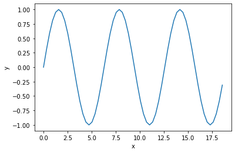

```python
x = np.arange(0,6*np.pi,0.1*np.pi)
plt.plot(x,np.sin(x))
plt.xlabel('x')
plt.ylabel('y')
```

### Example

- Plot $y=sin(x)$ for $x$ ranging from 0 to $6\pi$ in steps of $0.1\pi$.
  - Add a curve to show $y=cos(x)$.
  - Make the linewidths width 2
  - Make the $cos(x)$ curve have an opacity of 0.6.
  - Set the y limits to be (-1.5,1.5) and x limits of (0,5).
  - Add a title.
  - Set the fontsize of the title and labels to equal size 16.
  - Add a legend with labels for the curves.

### Solution

Click below to see the solution.

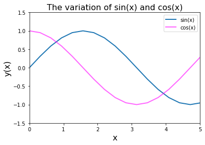

```python
plt.plot(x,np.sin(x),label='sin(x)',lw=2) #lw = thickness of line, label = the name of curve fn or datafile
plt.plot(x,np.cos(x),label='cos(x)',lw=2,c='magenta',alpha=0.6) # c=colour,alpha=transparency
plt.xlabel('x',fontsize=16)
plt.ylabel('y(x)',fontsize=16)
plt.ylim(-1.5,1.5)
plt.xlim(0,5)
plt.legend(loc='upper right')  # makes the legend
plt.title('The variation of sin(x) and cos(x)',fontsize=16) # add a title
```

### Example

Plot $y={\rm exp}\left(\dfrac{-x}{5}\right)$

### Solution

Click below to see the solution.

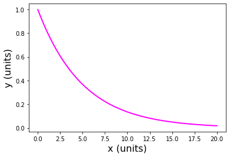

```python
import numpy as np
import pylab as plt # for plotting
# the line below makes the plot appear in the jupyter notebook
%matplotlib inline

# define function to calculate y
def func(x):
    return np.exp(-x / 5.0)

t = np.arange(0.01, 20.0, 0.01)
plt.plot(t, func(t),c='magenta',lw=2)
plt.xlabel('x (units)',fontsize=16)
plt.ylabel('y (units)',fontsize=16)
```

### Example

Plot $y={\rm exp}\left(\dfrac{-x}{5}\right)$ on different logscales.

### Solution

Click below to see the solution.

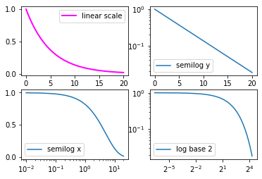

```python
plt.subplot(221) # makes a row=2 x column=2 grid of plots, 3rd number is index of each subplot 1-4
plt.plot(t, func(t),c='magenta',lw=2,label='linear scale')
plt.legend(loc='upper right')

plt.subplot(222)
plt.semilogy(t, func(t),label='semilog y')
plt.legend(loc='lower left')

plt.subplot(223)
plt.semilogx(t, func(t),label = 'semilog x')
plt.legend(loc='lower left')

plt.subplot(224)
plt.loglog(t,func(t),basex=2,label='log base 2')
plt.legend(loc='lower left')
```

### Example

Plot the data in the data file DataAnalysis_testfile.dat.

### Solution

Click below to see the solution.

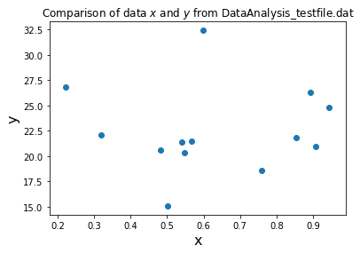

```python
data = np.genfromtxt('DataAnalysis_testfile.dat',names=True)
plt.scatter(data['x'],data['y'])
plt.xlabel('x',fontsize=16)
plt.ylabel('y',fontsize=16)
plt.title('Comparison of data $x$ and $y$ from DataAnalysis_testfile.dat')
```

We could also plot the above if we don't have any names for columns, see below:

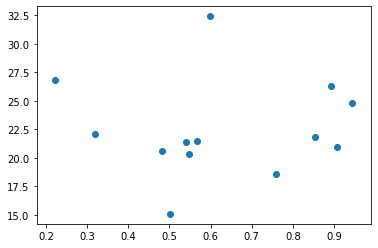

```python
data = np.genfromtxt('DataAnalysis_testfile.dat')
plt.scatter(data[:,0],data[:,1])
```

### Errobars

Often in physics, we have errors in our measurements. These can be easily added via the `errorbar` option in `matplotlib`.

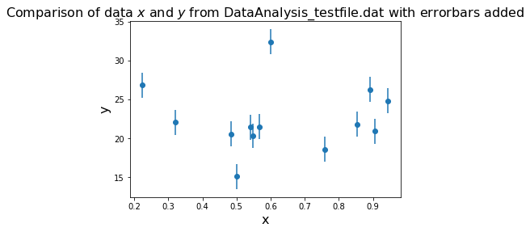

```python
data = np.genfromtxt('DataAnalysis_testfile.dat',names=True)
plt.errorbar(data['x'],data['y'],yerr=data['y_error'],fmt='o')
plt.xlabel('x',fontsize=16)
plt.ylabel('y',fontsize=16)
plt.title('Comparison of data $x$ and $y$ from DataAnalysis_testfile.dat with errorbars added',fontsize=16)
```

### Tip

All of the plotting options that can be used in matplotlib can be found [here](https://matplotlib.org/3.3.0/api/pyplot_summary.html).

# General Tips

- Make sure your code works in a new clean environment. In Colab: Runtime->restart Runtime, in Anaconda's Jupyter: Kernel->Restart.
- Dont forget to save your notebook regularly.
- Use spaces and empty lines to make program clearer.
- Add comments to your code so you know why you're doing something.
- Use sensible names for variables and functions, choose names you would be able to understand if you came back to your code a year later.
- With equations and calculations, use same variables as your equations in the notes/lectures so you will be able to directly compare. Do all of the calculation in the python cells, don't do part of it in your head/in your notes.
- Always have a markdown box before and after code cells explaining what you're going to do, and discussing the results.
- Don't forget to compile your cells, and run all before submitting assessed work.
- Don't be afraid to google for bits of code - particularly make use of the [SciPy](https://docs.scipy.org/) and [Python](https://www.python.org/doc/) documents.

Now you are ready to tackle the **Chapter 1 quiz** on Learning Central and the [Chapter1_yourturn notebook](https://github.com/haleygomez/Data-Analysis-2021/blob/master/blended_exercises/Chapter%201/Chapter1_yourturn.ipynb).